# Week Six

## Exam Review

## Simulation approach

Set some population parameters.

```r
p1 <- .016
p2 <- .005
theta <- p1/p2
theta
```

```
## [1] 3.2
```

## Simulation approach

Take a single sample.

```r
set.seed(384)
n1 <- 3338
n2 <- 2676
g1 <- sample(c(1, 0), size = n1,
             prob = c(p1, 1 - p1), replace = TRUE)
g2 <- sample(c(1, 0), size = n2,
             prob = c(p2, 1 - p2), replace = TRUE)
theta_hat <- mean(g1)/mean(g2)
theta_hat
```

```
## [1] 2.34777
```

## Simulation approach

Make a single bias estimate via bootstrap.

```r
it <- 5000
boot_RR<- rep(NA, it)
for (i in 1:it) {
  b1 <- sample(g1, size = n1, replace = TRUE)
  b2 <- sample(g2, size = n2, replace = TRUE)
  boot_RR[i] <- mean(b1)/mean(b2)
}
bias_hat <- mean(boot_RR) - theta_hat
bias_hat
```

```
## [1] 0.185618
```

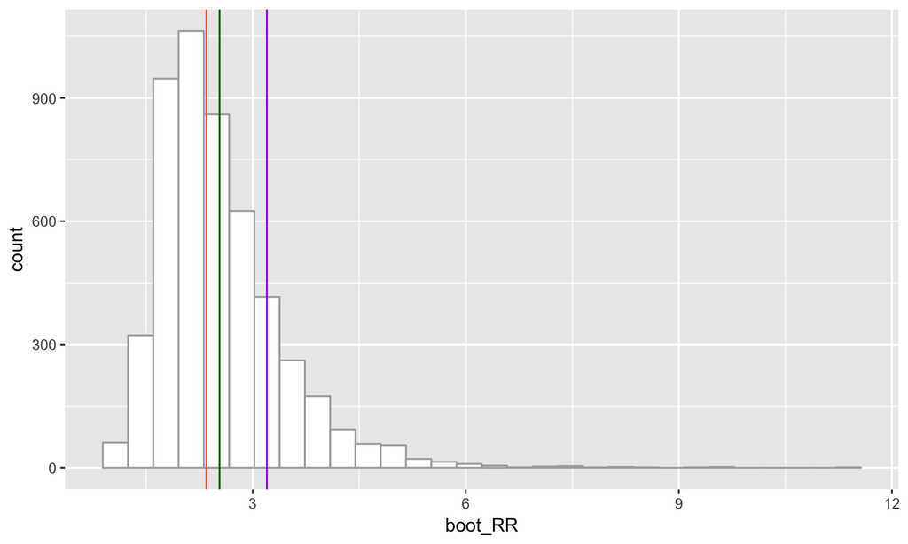

```r
library(tidyverse)
df <- data.frame(boot_RR)
ggplot(df, aes(x = boot_RR)) +
  geom_histogram(fill = "white", col = "darkgray") +
  geom_vline(xintercept = theta_hat, col = "tomato") +
  geom_vline(xintercept = mean(boot_RR), col = "darkgreen") +
  geom_vline(xintercept = theta, col = "purple")
```

## True bias

In the sim setting, we can find the true bias:

\[ E(\hat{\theta}) - \theta \]

Because we can learn (approximately) the first term via repeated simulation.

```r
theta_hats <- rep(NA, it)
for(i in 1:it) {
  g1 <- sample(c(1, 0), size = n1,
             prob = c(p1, 1 - p1), replace = TRUE)
  g2 <- sample(c(1, 0), size = n2,
             prob = c(p2, 1 - p2), replace = TRUE)
  theta_hats[i] <- mean(g1)/mean(g2)
}
bias <- mean(theta_hats[i]) - theta
bias
```

```
## [1] 0.6938629
```

## Sampling dist of \(\widehat{bias}_{boot}\)

The sampling distribution will of this statistic will tell us both its bias and its variance.

To make dreams inside of dreams we need to:

1. Generate a sample from the true parameters.
2. Build up a bootstrap distribution from sample.
3. Calculate a single \(\widehat{bias}_{boot} = E(\hat{\theta}^*) - \hat{\theta}\)
4. Repeat steps 1 - 3 to get a full distribution of \(\widehat{bias}_{boot}\).

## Sampling dist of \(\widehat{bias}_{boot}\)

```r
bias_hats_a <- rep(NA, it)
it <- 500
for (i in 1:it) {
  g1 <- sample(c(1, 0), size = n1,
             prob = c(p1, 1 - p1), replace = TRUE)
  g2 <- sample(c(1, 0), size = n2,
             prob = c(p2, 1 - p2), replace = TRUE)
  theta_hat <- mean(g1)/mean(g2)
  boot_RR<- rep(NA, it)
  for (j in 1:it) {
    b1 <- sample(g1, size = n1, replace = TRUE)
    b2 <- sample(g2, size = n2, replace = TRUE)
    boot_RR[j] <- mean(b1)/mean(b2)
  }
  bias_hats_a[i] <- mean(boot_RR) - theta_hat
}
```

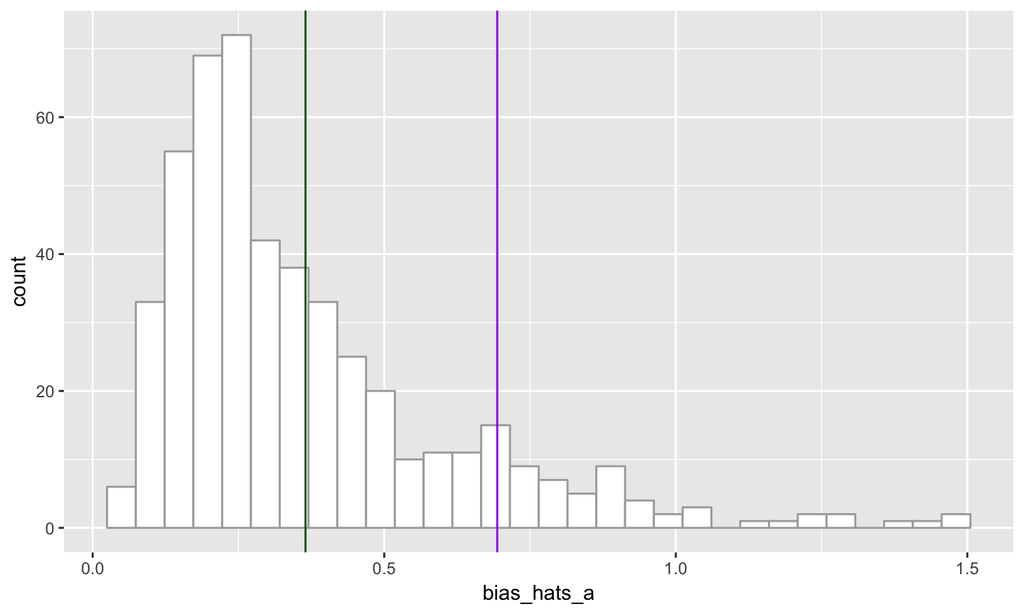

```r
bias_hats_a[bias_hats_a == Inf] <- NA
df <- data.frame(bias_hats_a)
ggplot(df, aes(x = bias_hats_a)) +
  geom_histogram(fill = "white", col = "darkgray") +
  geom_vline(xintercept = mean(bias_hats_a, na.rm = TRUE), col = "darkgreen") +
  geom_vline(xintercept = bias, col = "purple")
```

## Double Bootstrap

```r
bias_hats_b <- rep(NA, it)
for (i in 1:it) {
  g1_boot <- sample(g1, size = n1, replace = TRUE) #first boot
  g2_boot <- sample(g2, size = n2, replace = TRUE)
  theta_hat <- mean(g1_boot)/mean(g2_boot)
  boot_RR <- rep(NA, it)
  for (j in 1:it) {
    g1_boot_b <- sample(g1_boot, size = n1, replace = TRUE) #double boot!
    g2_boot_b <- sample(g2_boot, size = n1, replace = TRUE)
    boot_RR[j] <- mean(g1_boot_b)/mean(g2_boot_b)
  }
  bias_hats_b[i] <- mean(boot_RR) - theta_hat
}
```

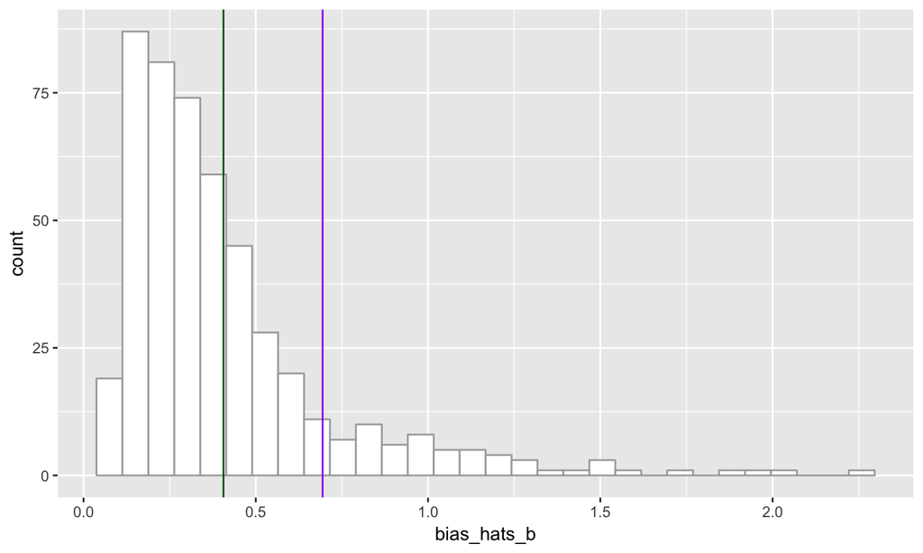

```r
bias_hats_b[bias_hats_b == Inf] <- NA
df <- data.frame(bias_hats_b)
ggplot(df, aes(x = bias_hats_b)) +
  geom_histogram(fill = "white", col = "darkgray") +
  geom_vline(xintercept = mean(bias_hats_b, na.rm = TRUE), col = "darkgreen") +
  geom_vline(xintercept = bias, col = "purple")
```

## Biases compared

```r
mean(bias_hats_a, na.rm = TRUE) - bias
```

```
## [1] -0.3288258
```

```r
mean(bias_hats_b, na.rm = TRUE) - bias
```

```
## [1] -0.2876878
```

## Variances compared

```r
sd(bias_hats_a, na.rm = TRUE)
```

```
## [1] 0.2514121
```

```r
sd(bias_hats_b, na.rm = TRUE)
```

```
## [1] 0.3163629
```

## Confidence Intervals

## Unknown sigma

```r
it <- 10000
w <- rep(NA, it)
n <- 15
for(i in 1:it) {
  x <- rnorm(n, 25, 7)
  xbar <- mean(x)
  s <- sd(x)
  w[i] <- (xbar - 25) / (s/sqrt(n))
}
qqnorm(w, pch = ".")
abline(0, 1)
```

## Unknown sigma

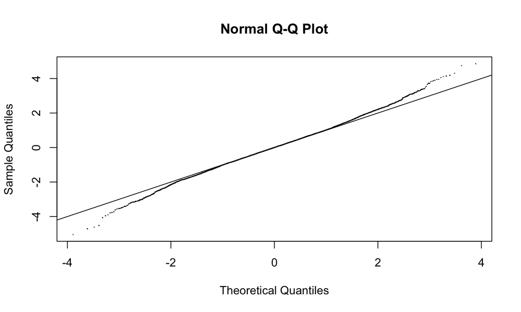

## t Distribution

Degrees of freedom = 1

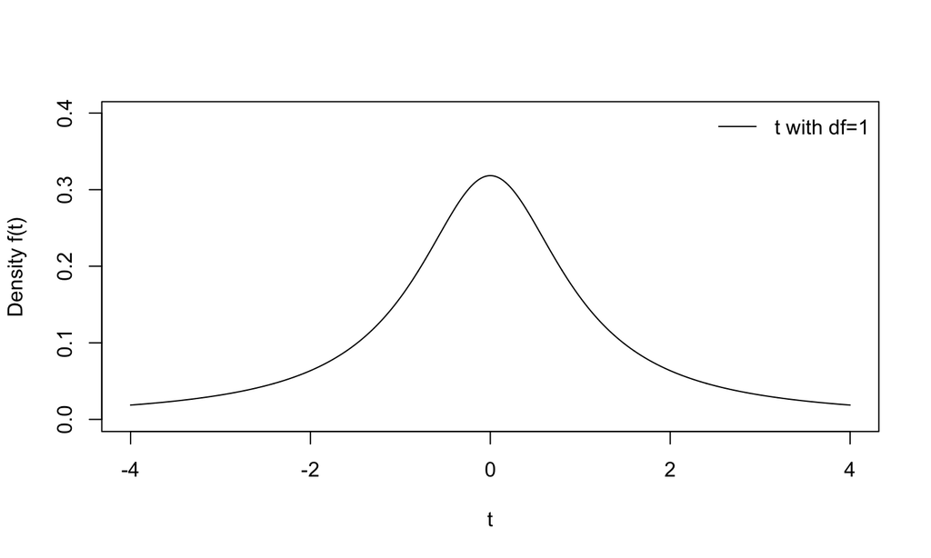

## t Distribution

Degrees of freedom = 3

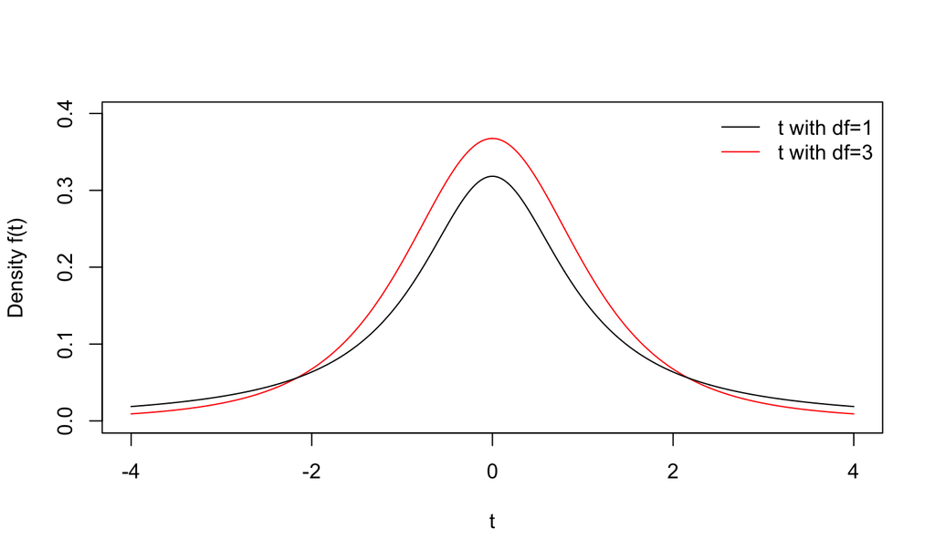

## t Distribution

Degrees of freedom = 7

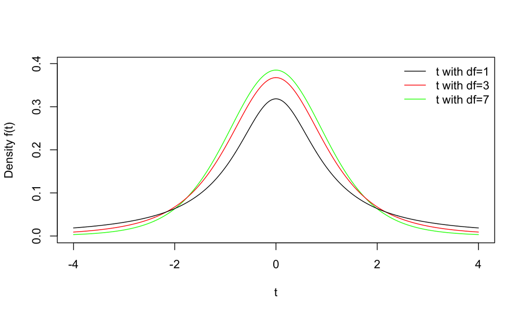

## t Distribution

At Degrees of freedom = \(\infty\), the \(t\) becomes a \(Z \sim N(0,1)\)

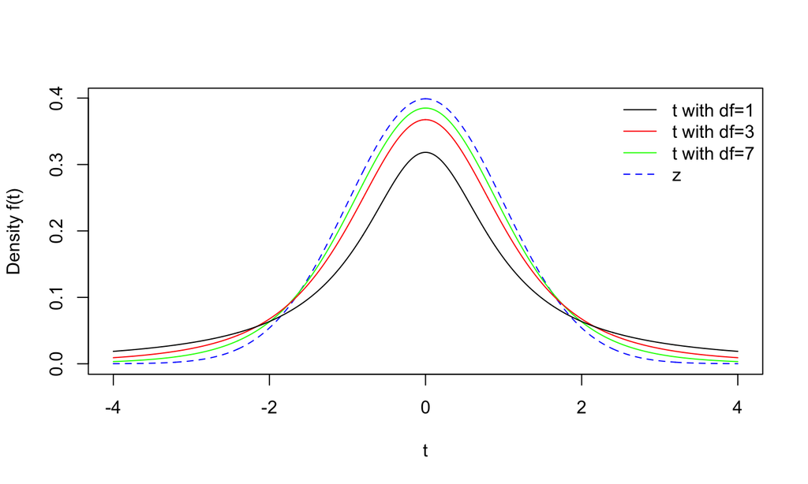

## Baby weights

```r
library(resampledata)
data(NCBirths2004)
girls <- NCBirths2004 %>%
  filter(Gender == "Female") %>%
  select(Weight) %>%
  pull()
```

## Baby weights, cont.

Step 1: is \(X\) normal?

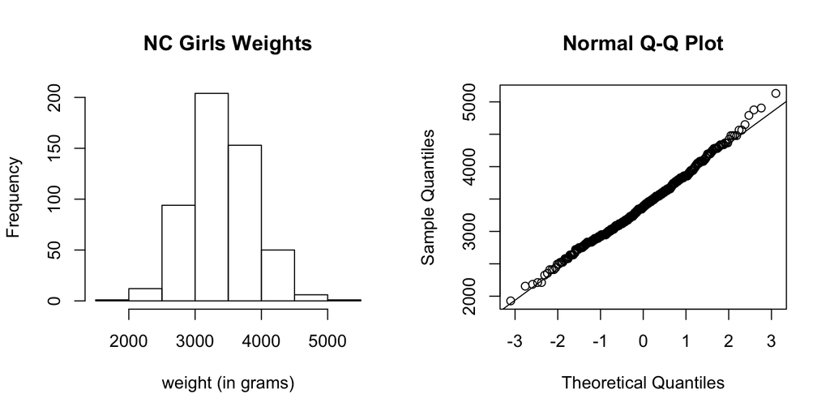

## Baby weights, cont.

Form the 95% interval from the statistics.

```r
x_bar <- mean(girls)
s <- sd(girls)
n <- length(girls)
alpha <- .05
q1 <- qt(alpha/2, df = n - 1)
q2 <- qt(1 - alpha/2, df = n - 1)
LB <- x_bar - q2 * s / sqrt(n)
UB <- x_bar - q1 * s / sqrt(n)
c(LB, UB)
```

```
## [1] 3356.514 3440.119
```

## Baby weights, cont.

Alternatively, the canned version.

```r
t.test(girls, conf.level=0.95)
```

```
##
##  One Sample t-test
##
## data:  girls
## t = 159.71, df = 520, p-value < 2.2e-16
## alternative hypothesis: true mean is not equal to 0
## 95 percent confidence interval:
##  3356.514 3440.119
## sample estimates:
## mean of x
##  3398.317
```

## Approximate Intervals

## Skew vs Sample Size

Say we have the following skewed population distribution and we are interested in \(\overline{x}\):

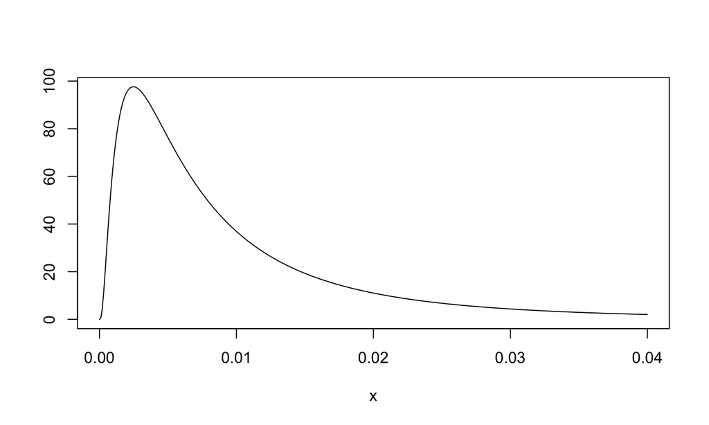

rlnorm(n meanlog = -5, sdlog = 1)

## Skew vs Sample Size

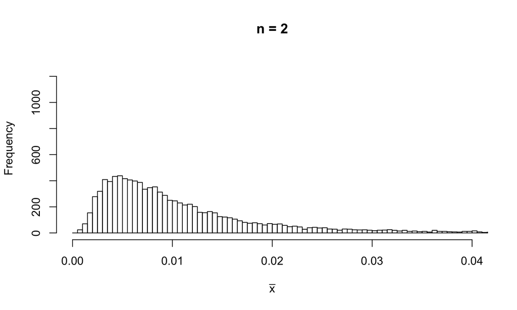

## Skew vs Sample Size

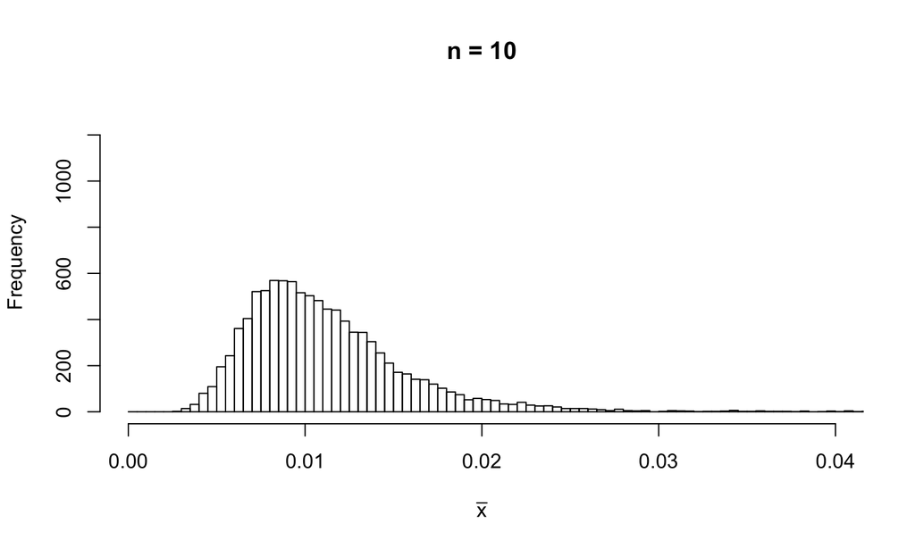

## Skew vs Sample Size

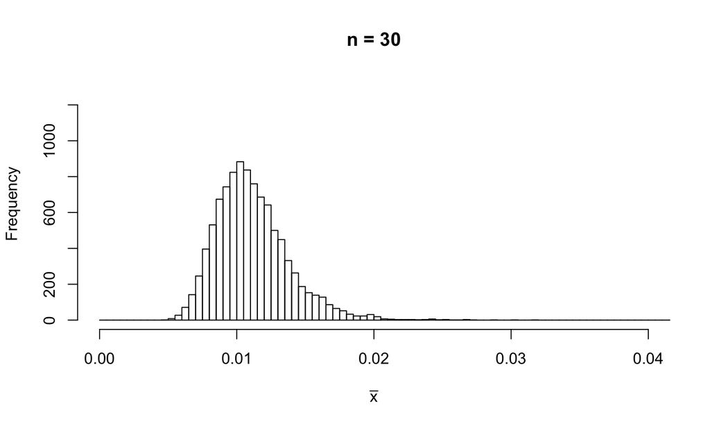

## Skew vs Sample Size

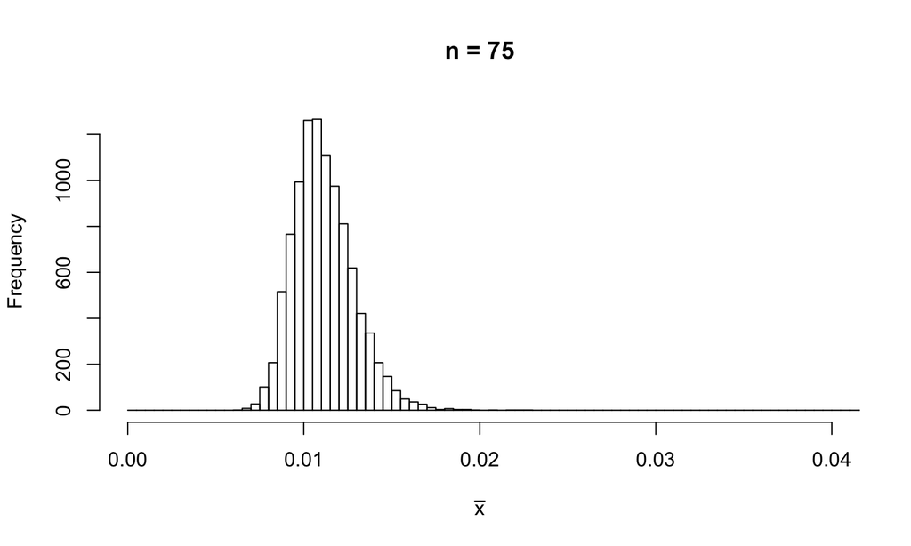

## Skew vs Sample Size

Now say we have the following population distribution and we are interested in the behavior of \(\overline{x}\) for sample size \(n\).

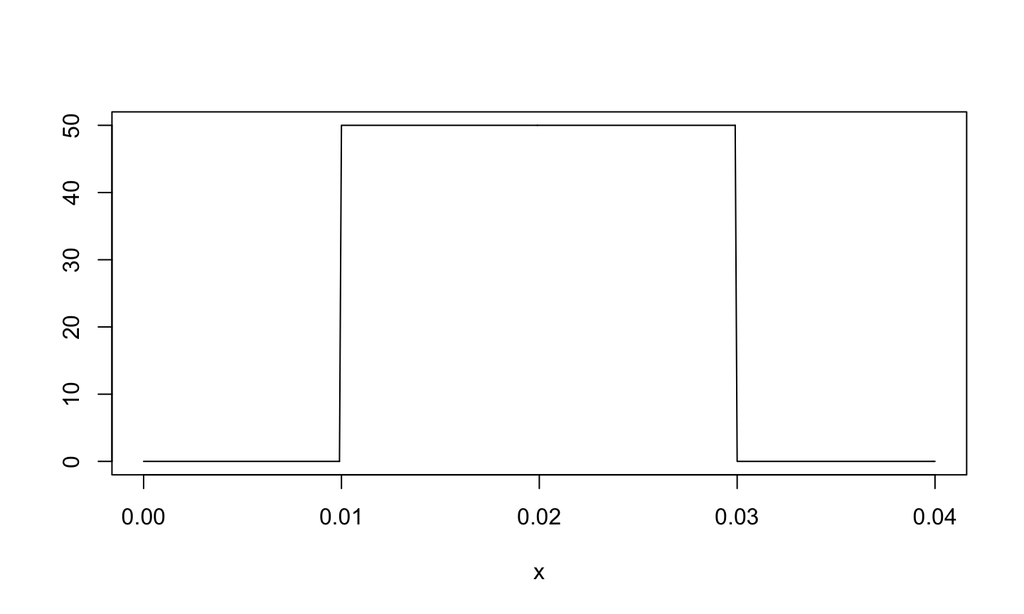

## Skew vs Sample Size

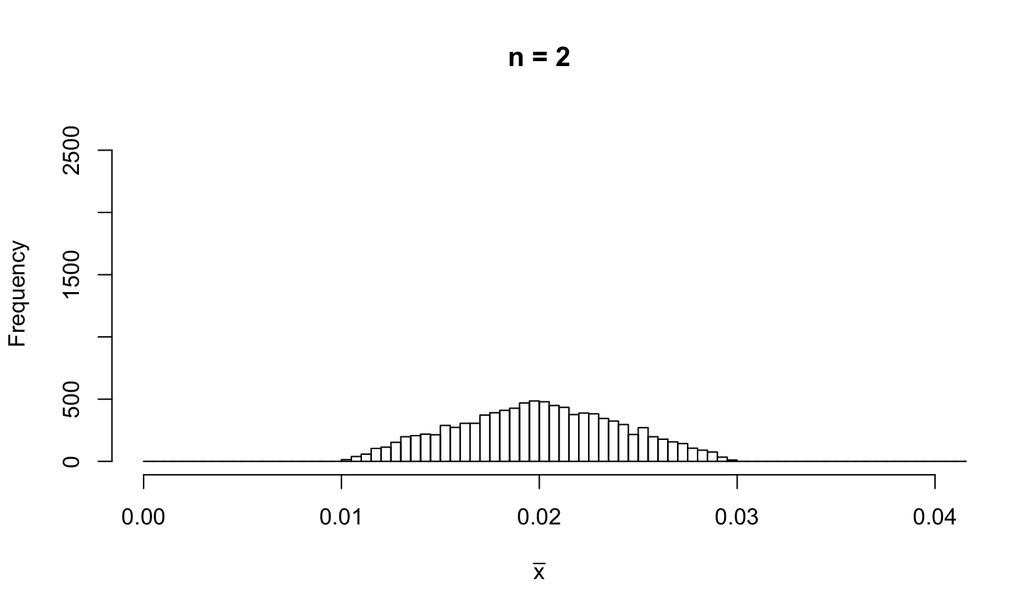

## Skew vs Sample Size

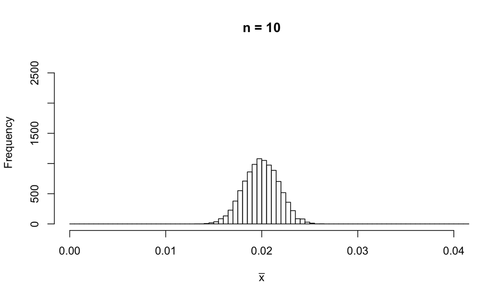

## Skew vs Sample Size

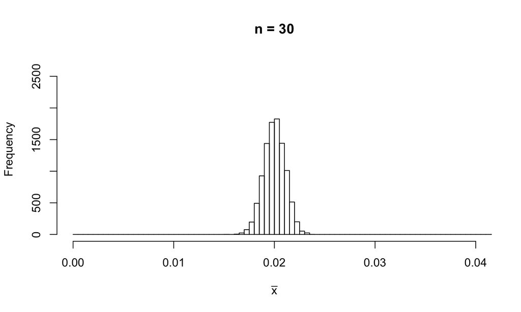

## Skew vs Sample Size

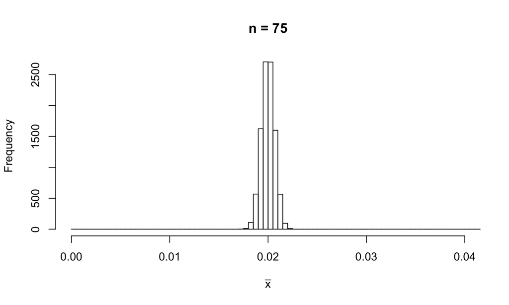

## Bootstrap t

```r
n <- 30
x <- rlnorm(n, meanlog = -5, sdlog = 1)
```

## Takehome

- At large sample sizes, the Normal approximation to a mean (or a standardized mean) via the CLT becomes useful for finding intervals for populations that are not well-behaved.
- If you have only a small sample from a highly skewed populations, you are likely stuck.